# Two Factor ANOVA

Simon Thornewill von Essen

29 1 2020

```r
data("warpbreaks")
head(warpbreaks, 2)
```

```
##   breaks wool tension
## 1     26    A       L
## 2     30    A       L
```

For this dataset, we just the number of warp break per loom (fixed length of yarn). Columns correspond to the number of breaks, the type of wool (A or B) and the level of tension (Low, Medium, High).

We can do a pivot table on this data to see the number of observations for each kind of break.

```r
table(warpbreaks$wool, warpbreaks$tension)
```

```
##
##     L M H
##   A 9 9 9
##   B 9 9 9
```

We have 9 observations for each kind of break, this means that the sample has an even distribution of breaks, which is good.

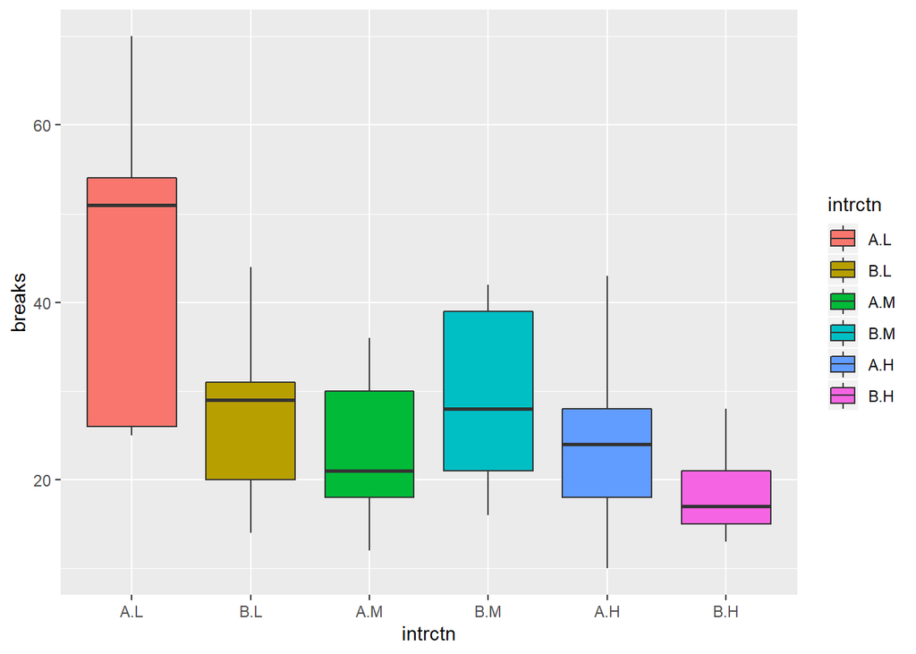

```r
warpbreaks$intrctn <- interaction(warpbreaks$wool, warpbreaks$tension)

ggplot(data=warpbreaks, aes(x=intrctn, y=breaks, fill=intrctn)) +
  geom_boxplot()
```

From this visualization, it looks like both factors may play a role in the number of breaks. It appears that there is a general decrease in breaks as we move from low to medium to high tension. Let’s start with a one-way model using tension only.

## One way Model

```r
mod1_string = " model {
    for( i in 1:length(y)) {
        y[i] ~ dnorm(mu[tensGrp[i]], prec)
    }

    for (j in 1:3) {
        mu[j] ~ dnorm(0.0, 1.0/1.0e6)
    }

    prec ~ dgamma(5/2.0, 5*2.0/2.0)
    sig = sqrt(1.0 / prec)
} "

data1_jags = list(y=log(warpbreaks$breaks), tensGrp=as.numeric(warpbreaks$tension))

params1 = c("mu", "sig")

mod1 = jags.model(textConnection(mod1_string), data=data1_jags, n.chains=3)
```

[figure not shown]

```r
update(mod1, 1e3)

mod1_sim = coda.samples(model=mod1,
                        variable.names=params1,
                        n.iter=5e3)

## convergence diagnostics
plot(mod1_sim)
```

```r
summary(mod1_sim)
```

```
##
## Iterations = 1001:6000
## Thinning interval = 1
## Number of chains = 3
## Sample size per chain = 5000
##
## 1. Empirical mean and standard deviation for each variable,
##    plus standard error of the mean:
##
##        Mean      SD  Naive SE Time-series SE
## mu[1] 3.500 0.13788 0.0011258      0.0011356
## mu[2] 3.213 0.13650 0.0011146      0.0011068
## mu[3] 3.012 0.13551 0.0011065      0.0011065
## sig   0.573 0.05529 0.0004515      0.0004792
##
## 2. Quantiles for each variable:
##
##         2.5%   25%    50%    75% 97.5%
## mu[1] 3.2290 3.408 3.4990 3.5915 3.770
## mu[2] 2.9442 3.121 3.2126 3.3042 3.478
## mu[3] 2.7449 2.922 3.0122 3.1033 3.278
## sig   0.4767 0.534 0.5688 0.6077 0.691
```

```r
dic1 <- dic.samples(mod1, n.iter = 1e3)

dic1
```

```
## Mean deviance:  66.54
## penalty 4.092
## Penalized deviance: 70.63
```

## Two Way Model

With two factors, we have six treatment groups. We will first fir the additive model, which treats the two factors separately with no interaction.

```r
# Create design matrix
X <- model.matrix(~ wool + tension, data=warpbreaks)
head(X)
```

```
##   (Intercept) woolB tensionM tensionH
## 1           1     0        0        0
## 2           1     0        0        0
## 3           1     0        0        0
## 4           1     0        0        0
## 5           1     0        0        0
## 6           1     0        0        0
```

```r
tail(X)
```

```
##    (Intercept) woolB tensionM tensionH
## 49           1     1        0        1
## 50           1     1        0        1
## 51           1     1        0        1
## 52           1     1        0        1
## 53           1     1        0        1
## 54           1     1        0        1
```

R has chosen the mean for wool A and low tension to be the intercept.

Now, we can build our model.

```r
mod2_string <- "model{
  for(i in 1:length(y)){
    y[i] ~ dnorm(mu[i], prec)
    mu[i] = int + alpha*isWoolB[i] + beta[1]*isTensionM[i] + beta[2]*isTensionH[i]
  }

  int ~ dnorm(0.0, 1.0/1.0e6)
  alpha ~ dnorm(0.0, 1.0/1.0e6)

  for(j in 1:2){
    beta[j] ~ dnorm(0.0, 1.0/1.0e6)
  }

  prec ~ dgamma(3/2.0, 3*1.0/2.0)
  sig = sqrt(1.0 / prec)
}"

data2_jags <- list(y=log(warpbreaks$breaks), isWoolB=X[,"woolB"], isTensionM=X[,"tensionM"], isTensionH=X[,"tensionH"])

params2 <- c("int", "alpha", "beta", "sig")

mod2 <- jags.model(textConnection(mod2_string), data=data2_jags, n.chains=3)
```

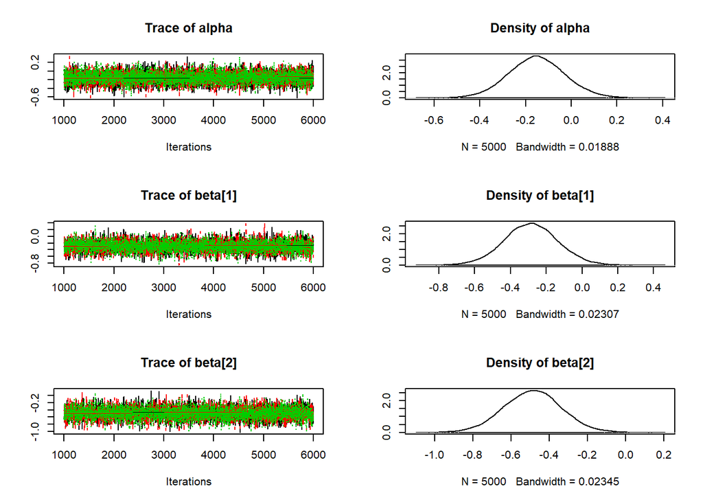

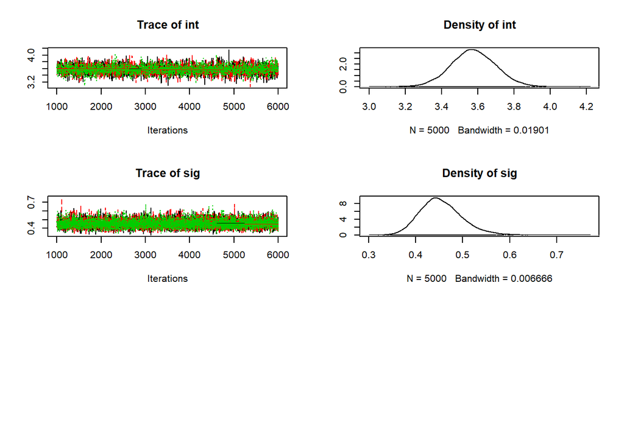

```r
update(mod2, 1e3)

mod2_sim <- coda.samples(model=mod2,
                        variable.names=params2,
                        n.iter=5e3)

plot(mod2_sim)
```

```r
summary(mod2_sim)
```

```
##
## Iterations = 1001:6000
## Thinning interval = 1
## Number of chains = 3
## Sample size per chain = 5000
##
## 1. Empirical mean and standard deviation for each variable,
##    plus standard error of the mean:
##
##            Mean      SD  Naive SE Time-series SE
## alpha   -0.1518 0.12283 0.0010029       0.001678
## beta[1] -0.2867 0.15113 0.0012340       0.002425
## beta[2] -0.4891 0.15202 0.0012413       0.002418
## int      3.5759 0.12328 0.0010066       0.002442
## sig      0.4539 0.04453 0.0003636       0.000392
##
## 2. Quantiles for each variable:
##
##            2.5%     25%     50%      75%    97.5%
## alpha   -0.3931 -0.2339 -0.1529 -0.07057  0.09360
## beta[1] -0.5860 -0.3870 -0.2867 -0.18742  0.01026
## beta[2] -0.7898 -0.5916 -0.4883 -0.38883 -0.18879
## int      3.3345  3.4933  3.5741  3.65776  3.82216
## sig      0.3763  0.4231  0.4501  0.48078  0.55257
```

```r
dic2 <- dic.samples(mod2, n.iter=1e3)

dic1
```

```
## Mean deviance:  66.54
## penalty 4.092
## Penalized deviance: 70.63
```

```r
dic2
```

```
## Mean deviance:  55.49
## penalty 5.273
## Penalized deviance: 60.76
```

We can see that the DIC has gone down a little bit by adding the wool factor to the model. But if we look at the aplot showing the breaks for string B, we can see that there are more breaks than string 1 when under moderate tension. Hence, it might be appropriate to add an interaction term.

```r
lmod2 <- lm(log(breaks) ~ .^2, data=warpbreaks)

summary(lmod2)
```

```
##
## Call:
## lm(formula = log(breaks) ~ .^2, data = warpbreaks)
##
## Residuals:
##      Min       1Q   Median       3Q      Max
## -0.81504 -0.27885  0.04042  0.27319  0.64358
##
## Coefficients: (20 not defined because of singularities)
##                     Estimate Std. Error t value Pr(>|t|)
## (Intercept)           3.7179     0.1247  29.824  < 2e-16 ***
## woolB                -0.2135     0.1763  -1.211  0.23189
## tensionM             -0.1951     0.2493  -0.783  0.43765
## tensionH             -0.6003     0.1763  -3.405  0.00134 **
## intrctnB.L           -0.2221     0.2493  -0.891  0.37749
## intrctnA.M           -0.4060     0.2493  -1.629  0.10995
## intrctnB.M                NA         NA      NA       NA
## intrctnA.H                NA         NA      NA       NA
## intrctnB.H                NA         NA      NA       NA
## woolB:tensionM            NA         NA      NA       NA
## woolB:tensionH            NA         NA      NA       NA
## woolB:intrctnB.L          NA         NA      NA       NA
## woolB:intrctnA.M          NA         NA      NA       NA
## woolB:intrctnB.M          NA         NA      NA       NA
## woolB:intrctnA.H          NA         NA      NA       NA
## woolB:intrctnB.H          NA         NA      NA       NA
## tensionM:intrctnB.L       NA         NA      NA       NA
## tensionH:intrctnB.L       NA         NA      NA       NA
## tensionM:intrctnA.M       NA         NA      NA       NA
## tensionH:intrctnA.M       NA         NA      NA       NA
## tensionM:intrctnB.M       NA         NA      NA       NA
## tensionH:intrctnB.M       NA         NA      NA       NA
## tensionM:intrctnA.H       NA         NA      NA       NA
## tensionH:intrctnA.H       NA         NA      NA       NA
## tensionM:intrctnB.H       NA         NA      NA       NA
## tensionH:intrctnB.H       NA         NA      NA       NA
## ---
## Signif. codes:  0 '***' 0.001 '**' 0.01 '*' 0.05 '.' 0.1 ' ' 1
##
## Residual standard error: 0.374 on 48 degrees of freedom
## Multiple R-squared:  0.3363, Adjusted R-squared:  0.2672
## F-statistic: 4.864 on 5 and 48 DF,  p-value: 0.001116
```

To model this in RJAGS

```r
mod3_string <- "model{
  for(i in 1:length(y)){
    y[i] ~ dnorm(mu[woolGrp[i], tensGrp[i]], prec)
  }

  for(j in 1:max(woolGrp)){
    for(k in 1:max(tensGrp)){
      mu[j, k] ~ dnorm(0.0, 1.0/1.0e6)
    }
  }
  prec ~ dgamma(3/2.0, 3*1.0/2.0)
  sig = sqrt(1.0 / prec)
}"

data3_jags <- list(y=log(warpbreaks$breaks), woolGrp=as.numeric(warpbreaks$wool), tensGrp=as.numeric(warpbreaks$tension))

params3 <- c("mu", "sig")

mod3 <- jags.model(textConnection(mod3_string), data=data3_jags, n.chains=3)
update(mod3, 1e3)

mod3_sim <- coda.samples(model=mod3,
                        variable.names=params3,
                        n.iter=5e3)
mod3_csim <- as.mcmc(do.call(rbind, mod3_sim))
```

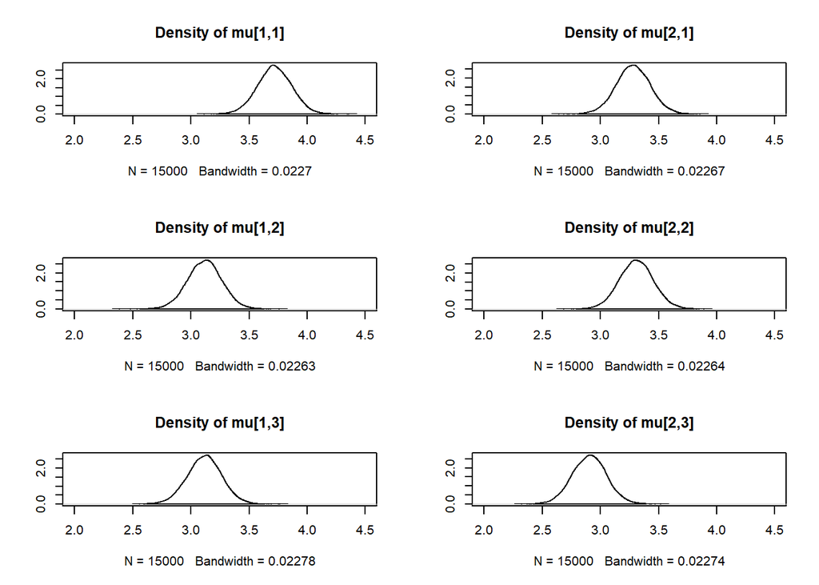

```r
par(mfrow=c(3,2)) # arrange frame for plots
densplot(mod3_csim[,1:6], xlim=c(2.0, 4.5))
```

Note, that while it might be tempting to look at comparisons between the combination of treatments, but it might lead to false positives. It’s best not to search results for interesting hypotheses, because if there are many hypotheses then some will appear to show associations simply due to random chance.

Results are most reliable when we determine a relatively small number of hypotheses we are interested in beforehand, collect the data and then statistically evaluate the evidence for them.

One question we might be interested in is finding the treatment combo that produces the fewest breaks. To calculate this, we can go through our posterior samples and for each simple, fine out which group has the smallest mean.

```r
prop.table( table( apply(mod3_csim[,1:6], 1, which.min) ) )
```

```
##
##          2          3          4          5          6
## 0.01653333 0.11820000 0.01020000 0.11866667 0.73640000
```

The evidence supports wool B with high tension as the treatment that produces the fewest breaks.